# ANCOVA in TDE - Escrita (TDE - Escrita)

Geiser C. Challco geiser@alumni.usp.br

- Descriptive Statistics of Initial Data
- ANCOVA and Pairwise for one factor: **grupo**
  - Without remove non-normal data
  - Computing ANCOVA and PairWise After removing non-normal data (OK)
    - Plots for ancova
    - Checking linearity assumption
    - Checking normality and homogeneity
- ANCOVA and Pairwise for two factors **grupo:Sexo**
  - Without remove non-normal data
  - Computing ANCOVA and PairWise After removing non-normal data (OK)
    - Plots for ancova
    - Checking linearity assumption
    - Checking normality and homogeneity
- ANCOVA and Pairwise for two factors **grupo:Zona**
  - Without remove non-normal data
  - Computing ANCOVA and PairWise After removing non-normal data (OK)
    - Plots for ancova
    - Checking linearity assumption
    - Checking normality and homogeneity
- ANCOVA and Pairwise for two factors **grupo:Cor.Raca**
  - Without remove non-normal data
  - Computing ANCOVA and PairWise After removing non-normal data (OK)
    - Plots for ancova
    - Checking linearity assumption
    - Checking normality and homogeneity
- ANCOVA and Pairwise for two factors **grupo:score.tde.quintile**
  - Without remove non-normal data
  - Computing ANCOVA and PairWise After removing non-normal data (OK)
    - Plots for ancova
    - Checking linearity assumption
    - Checking normality and homogeneity
- Summary of Results
  - Descriptive Statistics
  - ANCOVA Table Comparison
  - PairWise Table Comparison
  - EMMS Table Comparison

**NOTE**:

- Teste ANCOVA para determinar se houve diferenças significativas no TDE - Escrita (medido usando pre- e pos-testes).
- ANCOVA test to determine whether there were significant differences in TDE - Escrita (measured using pre- and post-tests).

# Descriptive Statistics of Initial Data

```r
df <- get.descriptives(dat, c(dv.pre, dv.pos), c("grupo"),
                       include.global = T, symmetry.test = T, normality.test = F)
df <- plyr::rbind.fill(
  df, do.call(plyr::rbind.fill, lapply(lfatores2, FUN = function(f) {
    if (nrow(dat) > 0 && sum(!is.na(unique(dat[[f]]))) > 1)
      get.descriptives(dat, c(dv.pre,dv.pos), c("grupo", f),
                       symmetry.test = T, normality.test = F)
    }))
)
(df <- df[,c(fatores1[fatores1 %in% colnames(df)],"variable",
             colnames(df)[!colnames(df) %in% c(fatores1,"variable")])])
```

```
##           grupo Sexo   Zona Cor.Raca score.tde.quintile      variable   n   mean median min max     sd    se
## 1      Controle <NA>   <NA>     <NA>               <NA> score.tde.pre 121 46.950   51.0   0  75 17.124 1.557
## 2  Experimental <NA>   <NA>     <NA>               <NA> score.tde.pre 147 43.204   45.0   0  71 15.845 1.307
## 3          <NA> <NA>   <NA>     <NA>               <NA> score.tde.pre 268 44.896   48.0   0  75 16.510 1.008
## 4      Controle <NA>   <NA>     <NA>               <NA> score.tde.pos 121 46.397   50.0   0  73 16.448 1.495
## 5  Experimental <NA>   <NA>     <NA>               <NA> score.tde.pos 147 44.422   48.0   0  74 16.143 1.331
## 6          <NA> <NA>   <NA>     <NA>               <NA> score.tde.pos 268 45.313   49.0   0  74 16.280 0.994
## 7      Controle    F   <NA>     <NA>               <NA> score.tde.pre  56 47.339   50.5   3  69 14.906 1.992
## 8      Controle    M   <NA>     <NA>               <NA> score.tde.pre  65 46.615   51.0   0  75 18.938 2.349
## 9  Experimental    F   <NA>     <NA>               <NA> score.tde.pre  75 47.320   49.0   3  68 14.875 1.718
## 10 Experimental    M   <NA>     <NA>               <NA> score.tde.pre  72 38.917   40.5   0  71 15.783 1.860
## 11     Controle    F   <NA>     <NA>               <NA> score.tde.pos  56 46.446   51.0   3  69 15.114 2.020
## 12     Controle    M   <NA>     <NA>               <NA> score.tde.pos  65 46.354   48.0   0  73 17.633 2.187
## 13 Experimental    F   <NA>     <NA>               <NA> score.tde.pos  75 47.120   52.0   0  72 16.473 1.902
## 14 Experimental    M   <NA>     <NA>               <NA> score.tde.pos  72 41.611   43.0   0  74 15.406 1.816
```

[output cut: 98 more lines]

| grupo | Sexo | Zona | Cor.Raca | score.tde.quintile | variable | n | mean | median | min | max | sd | se | ci | iqr | symmetry | skewness | kurtosis |
| --- | --- | --- | --- | --- | --- | --- | --- | --- | --- | --- | --- | --- | --- | --- | --- | --- | --- |
| Controle |  |  |  |  | score.tde.pre | 121 | 46.950 | 51.0 | 0 | 75 | 17.124 | 1.557 | 3.082 | 15.00 | NO | -1.124 | 0.589 |
| Experimental |  |  |  |  | score.tde.pre | 147 | 43.204 | 45.0 | 0 | 71 | 15.845 | 1.307 | 2.583 | 22.00 | NO | -0.641 | -0.044 |
|  |  |  |  |  | score.tde.pre | 268 | 44.896 | 48.0 | 0 | 75 | 16.510 | 1.008 | 1.986 | 18.00 | NO | -0.851 | 0.174 |
| Controle |  |  |  |  | score.tde.pos | 121 | 46.397 | 50.0 | 0 | 73 | 16.448 | 1.495 | 2.960 | 20.00 | NO | -0.786 | 0.049 |
| Experimental |  |  |  |  | score.tde.pos | 147 | 44.422 | 48.0 | 0 | 74 | 16.143 | 1.331 | 2.631 | 22.50 | NO | -0.733 | 0.081 |
|  |  |  |  |  | score.tde.pos | 268 | 45.313 | 49.0 | 0 | 74 | 16.280 | 0.994 | 1.958 | 21.25 | NO | -0.755 | 0.078 |
| Controle | F |  |  |  | score.tde.pre | 56 | 47.339 | 50.5 | 3 | 69 | 14.906 | 1.992 | 3.992 | 13.25 | NO | -1.379 | 1.558 |
| Controle | M |  |  |  | score.tde.pre | 65 | 46.615 | 51.0 | 0 | 75 | 18.938 | 2.349 | 4.693 | 16.00 | NO | -0.947 | -0.063 |
| Experimental | F |  |  |  | score.tde.pre | 75 | 47.320 | 49.0 | 3 | 68 | 14.875 | 1.718 | 3.422 | 17.00 | NO | -1.094 | 0.916 |
| Experimental | M |  |  |  | score.tde.pre | 72 | 38.917 | 40.5 | 0 | 71 | 15.783 | 1.860 | 3.709 | 18.50 | YES | -0.278 | -0.214 |
| Controle | F |  |  |  | score.tde.pos | 56 | 46.446 | 51.0 | 3 | 69 | 15.114 | 2.020 | 4.048 | 17.50 | NO | -0.970 | 0.327 |
| Controle | M |  |  |  | score.tde.pos | 65 | 46.354 | 48.0 | 0 | 73 | 17.633 | 2.187 | 4.369 | 22.00 | NO | -0.660 | -0.252 |
| Experimental | F |  |  |  | score.tde.pos | 75 | 47.120 | 52.0 | 0 | 72 | 16.473 | 1.902 | 3.790 | 16.00 | NO | -1.096 | 0.415 |
| Experimental | M |  |  |  | score.tde.pos | 72 | 41.611 | 43.0 | 0 | 74 | 15.406 | 1.816 | 3.620 | 19.25 | YES | -0.403 | 0.201 |
| Controle |  | Rural |  |  | score.tde.pre | 45 | 47.956 | 50.0 | 3 | 69 | 14.488 | 2.160 | 4.353 | 15.00 | NO | -1.285 | 1.618 |
| Controle |  | Urbana |  |  | score.tde.pre | 15 | 56.667 | 58.0 | 16 | 75 | 13.952 | 3.602 | 7.727 | 11.50 | NO | -1.370 | 2.202 |
| Controle |  |  |  |  | score.tde.pre | 61 | 43.820 | 49.0 | 0 | 73 | 18.783 | 2.405 | 4.811 | 17.00 | NO | -0.919 | -0.304 |
| Experimental |  | Rural |  |  | score.tde.pre | 57 | 43.386 | 46.0 | 0 | 68 | 17.864 | 2.366 | 4.740 | 24.00 | NO | -0.736 | -0.128 |
| Experimental |  | Urbana |  |  | score.tde.pre | 31 | 40.806 | 44.0 | 3 | 71 | 16.808 | 3.019 | 6.165 | 24.50 | YES | -0.436 | -0.595 |
| Experimental |  |  |  |  | score.tde.pre | 59 | 44.288 | 43.0 | 11 | 65 | 13.169 | 1.714 | 3.432 | 18.00 | YES | -0.391 | -0.639 |
| Controle |  | Rural |  |  | score.tde.pos | 45 | 47.133 | 49.0 | 8 | 71 | 15.374 | 2.292 | 4.619 | 15.00 | NO | -0.806 | 0.091 |
| Controle |  | Urbana |  |  | score.tde.pos | 15 | 51.400 | 54.0 | 24 | 73 | 13.410 | 3.462 | 7.426 | 17.00 | YES | -0.311 | -0.738 |
| Controle |  |  |  |  | score.tde.pos | 61 | 44.623 | 50.0 | 0 | 73 | 17.774 | 2.276 | 4.552 | 26.00 | NO | -0.706 | -0.331 |
| Experimental |  | Rural |  |  | score.tde.pos | 57 | 43.877 | 49.0 | 0 | 72 | 18.014 | 2.386 | 4.780 | 24.00 | NO | -0.716 | -0.246 |
| Experimental |  | Urbana |  |  | score.tde.pos | 31 | 43.226 | 46.0 | 6 | 74 | 16.921 | 3.039 | 6.207 | 24.00 | YES | -0.408 | -0.559 |
| Experimental |  |  |  |  | score.tde.pos | 59 | 45.576 | 48.0 | 0 | 67 | 13.862 | 1.805 | 3.612 | 19.00 | NO | -0.837 | 0.500 |
| Controle |  |  | Branca |  | score.tde.pre | 8 | 54.750 | 54.0 | 45 | 65 | 8.031 | 2.839 | 6.714 | 13.00 | YES | 0.045 | -2.028 |
| Controle |  |  | Indígena |  | score.tde.pre | 2 | 57.500 | 57.5 | 50 | 65 | 10.607 | 7.500 | 95.297 | 7.50 | few data | 0.000 | 0.000 |
| Controle |  |  | Parda |  | score.tde.pre | 50 | 40.940 | 46.5 | 0 | 66 | 17.846 | 2.524 | 5.072 | 24.00 | NO | -0.796 | -0.501 |
| Controle |  |  |  |  | score.tde.pre | 61 | 50.508 | 53.0 | 2 | 75 | 16.193 | 2.073 | 4.147 | 13.00 | NO | -1.372 | 1.601 |
| Experimental |  |  | Branca |  | score.tde.pre | 9 | 52.333 | 58.0 | 40 | 67 | 11.705 | 3.902 | 8.997 | 21.00 | YES | -0.085 | -2.068 |
| Experimental |  |  | Indígena |  | score.tde.pre | 3 | 44.667 | 48.0 | 33 | 53 | 10.408 | 6.009 | 25.856 | 10.00 | few data | 0.000 | 0.000 |
| Experimental |  |  | Parda |  | score.tde.pre | 49 | 38.082 | 42.0 | 2 | 68 | 18.909 | 2.701 | 5.431 | 28.00 | YES | -0.282 | -1.003 |
| Experimental |  |  |  |  | score.tde.pre | 86 | 45.116 | 45.5 | 0 | 71 | 13.644 | 1.471 | 2.925 | 18.00 | NO | -0.631 | 0.419 |
| Controle |  |  | Branca |  | score.tde.pos | 8 | 56.000 | 55.5 | 43 | 72 | 9.885 | 3.495 | 8.264 | 13.50 | YES | 0.196 | -1.610 |
| Controle |  |  | Indígena |  | score.tde.pos | 2 | 56.500 | 56.5 | 50 | 63 | 9.192 | 6.500 | 82.590 | 6.50 | few data | 0.000 | 0.000 |
| Controle |  |  | Parda |  | score.tde.pos | 50 | 40.000 | 44.0 | 0 | 68 | 17.430 | 2.465 | 4.953 | 27.75 | NO | -0.681 | -0.532 |
| Controle |  |  |  |  | score.tde.pos | 61 | 50.049 | 53.0 | 15 | 73 | 14.723 | 1.885 | 3.771 | 18.00 | NO | -0.630 | -0.450 |
| Experimental |  |  | Branca |  | score.tde.pos | 9 | 52.222 | 52.0 | 23 | 72 | 14.558 | 4.853 | 11.191 | 8.00 | YES | -0.397 | -0.502 |
| Experimental |  |  | Indígena |  | score.tde.pos | 3 | 51.000 | 52.0 | 49 | 52 | 1.732 | 1.000 | 4.303 | 1.50 | few data | 0.000 | 0.000 |
| Experimental |  |  | Parda |  | score.tde.pos | 49 | 37.082 | 33.0 | 3 | 71 | 18.671 | 2.667 | 5.363 | 29.00 | YES | -0.056 | -1.143 |
| Experimental |  |  |  |  | score.tde.pos | 86 | 47.558 | 49.5 | 0 | 74 | 13.481 | 1.454 | 2.890 | 15.50 | NO | -1.089 | 2.018 |
| Controle |  |  |  | 1st quintile | score.tde.pre | 14 | 9.214 | 10.0 | 0 | 17 | 5.352 | 1.430 | 3.090 | 8.50 | YES | -0.236 | -1.339 |
| Controle |  |  |  | 2nd quintile | score.tde.pre | 7 | 25.143 | 26.0 | 19 | 29 | 3.716 | 1.405 | 3.437 | 5.00 | YES | -0.397 | -1.518 |
| Controle |  |  |  | 3rd quintile | score.tde.pre | 7 | 40.571 | 42.0 | 36 | 42 | 2.299 | 0.869 | 2.126 | 2.00 | NO | -1.031 | -0.650 |
| Controle |  |  |  | 4th quintile | score.tde.pre | 36 | 47.306 | 47.0 | 43 | 51 | 2.837 | 0.473 | 0.960 | 5.00 | YES | -0.266 | -1.302 |
| Controle |  |  |  | 5th quintile | score.tde.pre | 57 | 59.456 | 58.0 | 52 | 75 | 5.904 | 0.782 | 1.567 | 8.00 | NO | 0.697 | -0.330 |
| Experimental |  |  |  | 1st quintile | score.tde.pre | 12 | 9.000 | 10.5 | 0 | 17 | 6.310 | 1.822 | 4.009 | 11.50 | YES | -0.040 | -1.769 |
| Experimental |  |  |  | 2nd quintile | score.tde.pre | 21 | 26.238 | 27.0 | 19 | 31 | 3.491 | 0.762 | 1.589 | 5.00 | YES | -0.404 | -1.031 |
| Experimental |  |  |  | 3rd quintile | score.tde.pre | 32 | 38.375 | 40.0 | 32 | 42 | 3.309 | 0.585 | 1.193 | 5.25 | NO | -0.553 | -1.237 |
| Experimental |  |  |  | 4th quintile | score.tde.pre | 32 | 46.938 | 47.5 | 43 | 51 | 2.564 | 0.453 | 0.925 | 4.25 | YES | -0.200 | -1.211 |
| Experimental |  |  |  | 5th quintile | score.tde.pre | 50 | 59.240 | 58.5 | 52 | 71 | 5.141 | 0.727 | 1.461 | 7.75 | YES | 0.402 | -0.909 |
| Controle |  |  |  | 1st quintile | score.tde.pos | 14 | 15.286 | 15.0 | 0 | 28 | 9.384 | 2.508 | 5.418 | 15.00 | YES | -0.191 | -1.491 |
| Controle |  |  |  | 2nd quintile | score.tde.pos | 7 | 26.857 | 25.0 | 20 | 45 | 8.295 | 3.135 | 7.672 | 3.00 | NO | 1.378 | 0.355 |
| Controle |  |  |  | 3rd quintile | score.tde.pos | 7 | 39.857 | 40.0 | 26 | 56 | 11.539 | 4.361 | 10.672 | 16.50 | YES | 0.105 | -1.755 |
| Controle |  |  |  | 4th quintile | score.tde.pos | 36 | 47.444 | 48.5 | 28 | 62 | 7.527 | 1.254 | 2.547 | 9.00 | NO | -0.697 | 0.355 |
| Controle |  |  |  | 5th quintile | score.tde.pos | 57 | 56.579 | 58.0 | 31 | 73 | 10.046 | 1.331 | 2.666 | 12.00 | NO | -0.583 | -0.086 |
| Experimental |  |  |  | 1st quintile | score.tde.pos | 12 | 14.500 | 14.5 | 0 | 29 | 10.501 | 3.031 | 6.672 | 20.25 | YES | 0.090 | -1.694 |
| Experimental |  |  |  | 2nd quintile | score.tde.pos | 21 | 32.619 | 31.0 | 20 | 60 | 9.206 | 2.009 | 4.190 | 8.00 | NO | 1.233 | 1.532 |
| Experimental |  |  |  | 3rd quintile | score.tde.pos | 32 | 39.969 | 43.0 | 0 | 57 | 12.800 | 2.263 | 4.615 | 11.75 | NO | -1.358 | 1.721 |
| Experimental |  |  |  | 4th quintile | score.tde.pos | 32 | 48.250 | 49.5 | 28 | 59 | 6.951 | 1.229 | 2.506 | 5.25 | NO | -1.256 | 1.802 |
| Experimental |  |  |  | 5th quintile | score.tde.pos | 50 | 56.960 | 57.0 | 14 | 74 | 10.999 | 1.555 | 3.126 | 8.75 | NO | -1.730 | 4.357 |

# ANCOVA and Pairwise for one factor: **grupo**

## Without remove non-normal data

```r
pdat = remove_group_data(dat[!is.na(dat[["grupo"]]),], "score.tde.pos", "grupo")

pdat.long <- rbind(pdat[,c("id","grupo")], pdat[,c("id","grupo")])
pdat.long[["time"]] <- c(rep("pre", nrow(pdat)), rep("pos", nrow(pdat)))
pdat.long[["time"]] <- factor(pdat.long[["time"]], c("pre","pos"))
pdat.long[["score.tde"]] <- c(pdat[["score.tde.pre"]], pdat[["score.tde.pos"]])

aov = anova_test(pdat, score.tde.pos ~ score.tde.pre + grupo)
laov[["grupo"]] <- get_anova_table(aov)
```

```r
pwc <- emmeans_test(pdat, score.tde.pos ~ grupo, covariate = score.tde.pre,
                    p.adjust.method = "bonferroni")
```

```r
pwc.long <- emmeans_test(dplyr::group_by_at(pdat.long, "grupo"),
                          score.tde ~ time,
                          p.adjust.method = "bonferroni")
lpwc[["grupo"]] <- plyr::rbind.fill(pwc, pwc.long)
```

```r
ds <- get.descriptives(pdat, "score.tde.pos", "grupo", covar = "score.tde.pre")
ds <- merge(ds[ds$variable != "score.tde.pre",],
            ds[ds$variable == "score.tde.pre", !colnames(ds) %in% c("variable")],
            by = "grupo", all.x = T, suffixes = c("", ".score.tde.pre"))
ds <- merge(get_emmeans(pwc), ds, by = "grupo", suffixes = c(".emms", ""))
ds <- ds[,c("grupo","n","mean.score.tde.pre","se.score.tde.pre","mean","se","emmean","se.emms")]

colnames(ds) <- c("grupo", "N", paste0(c("M","SE")," (pre)"),
                  paste0(c("M","SE"), " (unadj)"), paste0(c("M", "SE"), " (adj)"))

lemms[["grupo"]] <- ds
```

## Computing ANCOVA and PairWise After removing non-normal data (OK)

```r
wdat = pdat

res = residuals(lm(score.tde.pos ~ score.tde.pre + grupo, data = wdat))
non.normal = getNonNormal(res, wdat$id, plimit = 0.05)

wdat = wdat[!wdat$id %in% non.normal,]

wdat.long <- rbind(wdat[,c("id","grupo")], wdat[,c("id","grupo")])
wdat.long[["time"]] <- c(rep("pre", nrow(wdat)), rep("pos", nrow(wdat)))
wdat.long[["time"]] <- factor(wdat.long[["time"]], c("pre","pos"))
wdat.long[["score.tde"]] <- c(wdat[["score.tde.pre"]], wdat[["score.tde.pos"]])

ldat[["grupo"]] = wdat

(non.normal)
```

```
##  [1] "P1128" "P1129" "P1139" "P1117" "P1126" "P1118" "P1149" "P3228" "P1152" "P3732" "P606"  "P609"  "P1111"
## [14] "P3221" "P3237" "P2327" "P1168"
```

```r
aov = anova_test(wdat, score.tde.pos ~ score.tde.pre + grupo)
laov[["grupo"]] <- merge(get_anova_table(aov), laov[["grupo"]], by="Effect", suffixes = c("","'"))

(df = get_anova_table(aov))
```

```
## ANOVA Table (type II tests)
##
##          Effect DFn DFd        F         p p<.05   ges
## 1 score.tde.pre   1 248 1317.152 3.38e-101     * 0.842
## 2         grupo   1 248    3.382  6.70e-02       0.013
```

| Effect | DFn | DFd | F | p | p<.05 | ges |
| --- | --- | --- | --- | --- | --- | --- |
| score.tde.pre | 1 | 248 | 1317.152 | 0.000 | * | 0.842 |
| grupo | 1 | 248 | 3.382 | 0.067 |  | 0.013 |

[output not shown]

```r
pwc.long <- emmeans_test(dplyr::group_by_at(wdat.long, "grupo"),
                         score.tde ~ time,
                         p.adjust.method = "bonferroni")
lpwc[["grupo"]] <- merge(plyr::rbind.fill(pwc, pwc.long), lpwc[["grupo"]], by=c("grupo","term",".y.","group1","group2"), suffixes = c("","'"))
```

| grupo | term | .y. | group1 | group2 | df | statistic | p | p.adj | p.adj.signif |
| --- | --- | --- | --- | --- | --- | --- | --- | --- | --- |
| Controle | time | score.tde | pre | pos | 498 | -0.313 | 0.754 | 0.754 | ns |
| Experimental | time | score.tde | pre | pos | 498 | -1.391 | 0.165 | 0.165 | ns |

```r
ds <- get.descriptives(wdat, "score.tde.pos", "grupo", covar = "score.tde.pre")
ds <- merge(ds[ds$variable != "score.tde.pre",],
            ds[ds$variable == "score.tde.pre", !colnames(ds) %in% c("variable")],
            by = "grupo", all.x = T, suffixes = c("", ".score.tde.pre"))
ds <- merge(get_emmeans(pwc), ds, by = "grupo", suffixes = c(".emms", ""))
ds <- ds[,c("grupo","n","mean.score.tde.pre","se.score.tde.pre","mean","se","emmean","se.emms")]

colnames(ds) <- c("grupo", "N", paste0(c("M","SE")," (pre)"),
                  paste0(c("M","SE"), " (unadj)"), paste0(c("M", "SE"), " (adj)"))

lemms[["grupo"]] <- merge(ds, lemms[["grupo"]], by=c("grupo"), suffixes = c("","'"))
```

| grupo | N | M (pre) | SE (pre) | M (unadj) | SE (unadj) | M (adj) | SE (adj) |
| --- | --- | --- | --- | --- | --- | --- | --- |
| Controle | 113 | 47.035 | 1.632 | 47.708 | 1.505 | 45.831 | 0.587 |
| Experimental | 138 | 43.051 | 1.371 | 45.754 | 1.296 | 47.291 | 0.531 |

### Plots for ancova

```r
plots <- oneWayAncovaPlots(
  wdat, "score.tde.pos", "grupo", aov, list("grupo"=pwc), addParam = c("mean_se"),
  font.label.size=10, step.increase=0.05, p.label="p.adj",
  subtitle = which(aov$Effect == "grupo"))
```

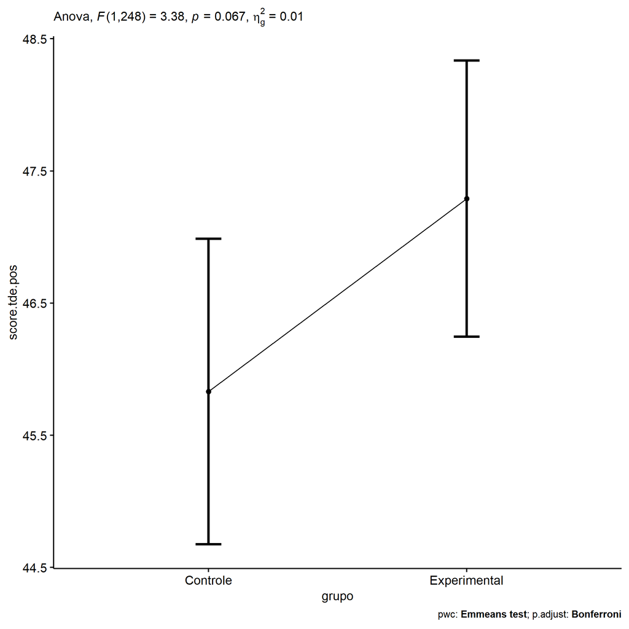

```r
if (!is.null(nrow(plots[["grupo"]]$data)))
  plots[["grupo"]] + ggplot2::scale_color_manual(values = color[["grupo"]])
```

```r
plots <- oneWayAncovaBoxPlots(
  wdat, "score.tde.pos", "grupo", aov, pwc, covar = "score.tde.pre",
  theme = "classic", color = color[["grupo"]],
  subtitle = which(aov$Effect == "grupo"))
```

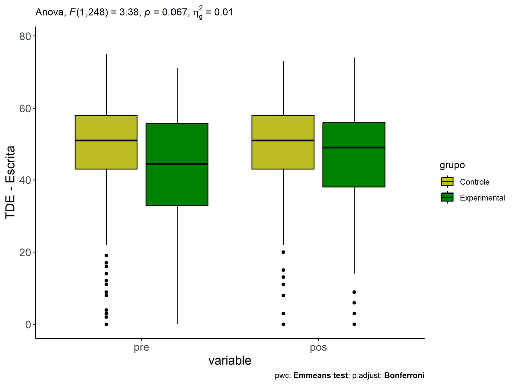

```r
if (length(unique(wdat[["grupo"]])) > 1)
  plots[["grupo"]] + ggplot2::ylab("TDE - Escrita") + ggplot2::scale_x_discrete(labels=c('pre', 'pos'))
```

```r
if (length(unique(wdat.long[["grupo"]])) > 1)
  plots <- oneWayAncovaBoxPlots(
    wdat.long, "score.tde", "grupo", aov, pwc.long, pre.post = "time",
    theme = "classic", color = color$prepost)
```

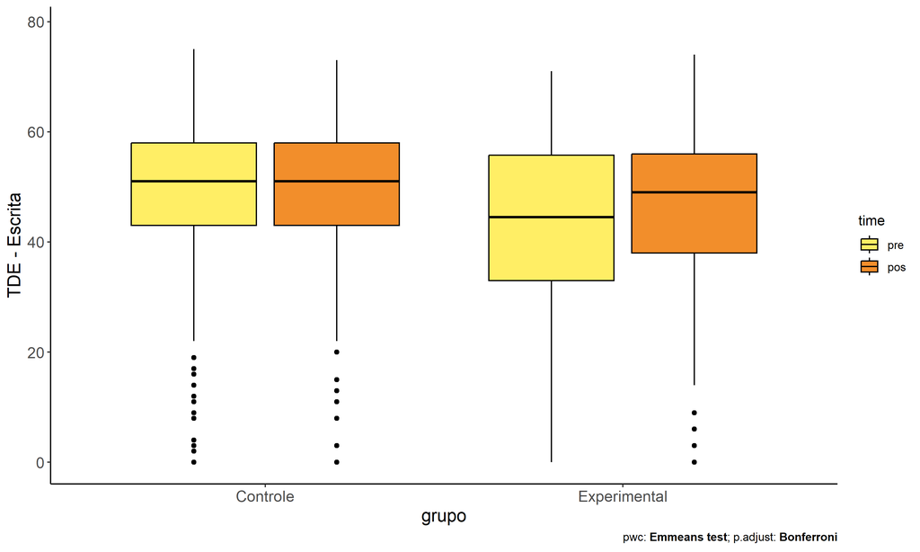

```r
if (length(unique(wdat.long[["grupo"]])) > 1)
  plots[["grupo"]] + ggplot2::ylab("TDE - Escrita")
```

### Checking linearity assumption

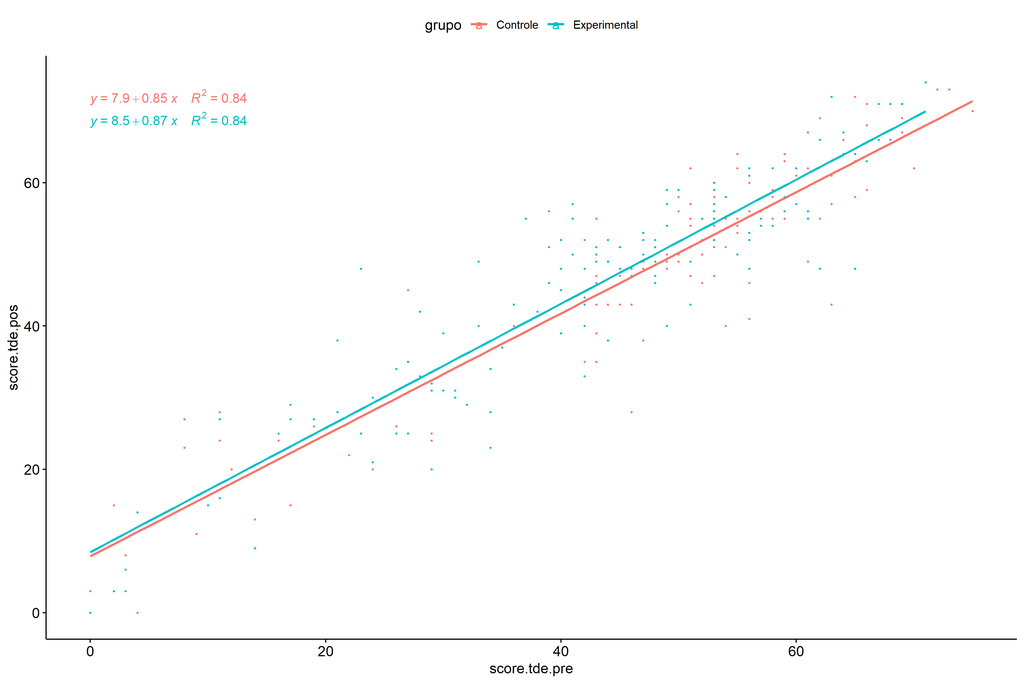

```r
ggscatter(wdat, x = "score.tde.pre", y = "score.tde.pos", size = 0.5,
          color = "grupo", add = "reg.line")+
  stat_regline_equation(
    aes(label =  paste(..eq.label.., ..rr.label.., sep = "~~~~"), color = grupo)
  )
```

### Checking normality and homogeneity

```r
res <- augment(lm(score.tde.pos ~ score.tde.pre + grupo, data = wdat))
```

```r
shapiro_test(res$.resid)
```

```
## # A tibble: 1 × 3
##   variable   statistic p.value
##   <chr>          <dbl>   <dbl>
## 1 res$.resid     0.990   0.101
```

```r
levene_test(res, .resid ~ grupo)
```

```
## # A tibble: 1 × 4
##     df1   df2 statistic     p
##   <int> <int>     <dbl> <dbl>
## 1     1   249    0.0644 0.800
```

# ANCOVA and Pairwise for two factors **grupo:Sexo**

## Without remove non-normal data

```r
pdat = remove_group_data(dat[!is.na(dat[["grupo"]]) & !is.na(dat[["Sexo"]]),], "score.tde.pos", c("grupo","Sexo"))

pdat.long <- rbind(pdat[,c("id","grupo","Sexo")], pdat[,c("id","grupo","Sexo")])
pdat.long[["time"]] <- c(rep("pre", nrow(pdat)), rep("pos", nrow(pdat)))
pdat.long[["time"]] <- factor(pdat.long[["time"]], c("pre","pos"))
pdat.long[["score.tde"]] <- c(pdat[["score.tde.pre"]], pdat[["score.tde.pos"]])

aov = anova_test(pdat, score.tde.pos ~ score.tde.pre + grupo*Sexo)
laov[["grupo:Sexo"]] <- get_anova_table(aov)
```

```r
pwcs <- list()
pwcs[["Sexo"]] <- emmeans_test(
  group_by(pdat, grupo), score.tde.pos ~ Sexo,
  covariate = score.tde.pre, p.adjust.method = "bonferroni")
pwcs[["grupo"]] <- emmeans_test(
  group_by(pdat, Sexo), score.tde.pos ~ grupo,
  covariate = score.tde.pre, p.adjust.method = "bonferroni")

pwc <- plyr::rbind.fill(pwcs[["grupo"]], pwcs[["Sexo"]])
pwc <- pwc[,c("grupo","Sexo", colnames(pwc)[!colnames(pwc) %in% c("grupo","Sexo")])]
```

```r
pwc.long <- emmeans_test(dplyr::group_by_at(pdat.long, c("grupo","Sexo")),
                         score.tde ~ time,
                         p.adjust.method = "bonferroni")
lpwc[["grupo:Sexo"]] <- plyr::rbind.fill(pwc, pwc.long)
```

```r
ds <- get.descriptives(pdat, "score.tde.pos", c("grupo","Sexo"), covar = "score.tde.pre")
ds <- merge(ds[ds$variable != "score.tde.pre",],
            ds[ds$variable == "score.tde.pre", !colnames(ds) %in% c("variable")],
            by = c("grupo","Sexo"), all.x = T, suffixes = c("", ".score.tde.pre"))
ds <- merge(get_emmeans(pwcs[["grupo"]]), ds, by = c("grupo","Sexo"), suffixes = c(".emms", ""))
ds <- ds[,c("grupo","Sexo","n","mean.score.tde.pre","se.score.tde.pre","mean","se","emmean","se.emms")]

colnames(ds) <- c("grupo","Sexo", "N", paste0(c("M","SE")," (pre)"),
                  paste0(c("M","SE"), " (unadj)"), paste0(c("M", "SE"), " (adj)"))

lemms[["grupo:Sexo"]] <- ds
```

## Computing ANCOVA and PairWise After removing non-normal data (OK)

```r
wdat = pdat

res = residuals(lm(score.tde.pos ~ score.tde.pre + grupo*Sexo, data = wdat))
non.normal = getNonNormal(res, wdat$id, plimit = 0.05)

wdat = wdat[!wdat$id %in% non.normal,]

wdat.long <- rbind(wdat[,c("id","grupo","Sexo")], wdat[,c("id","grupo","Sexo")])
wdat.long[["time"]] <- c(rep("pre", nrow(wdat)), rep("pos", nrow(wdat)))
wdat.long[["time"]] <- factor(wdat.long[["time"]], c("pre","pos"))
wdat.long[["score.tde"]] <- c(wdat[["score.tde.pre"]], wdat[["score.tde.pos"]])


ldat[["grupo:Sexo"]] = wdat

(non.normal)
```

```
##  [1] "P1128" "P1129" "P1139" "P1117" "P1126" "P1118" "P1149" "P609"  "P3228" "P1111" "P606"  "P3241" "P3732"
## [14] "P3221" "P3237" "P2327"
```

```r
aov = anova_test(wdat, score.tde.pos ~ score.tde.pre + grupo*Sexo)
laov[["grupo:Sexo"]] <- merge(get_anova_table(aov), laov[["grupo:Sexo"]], by="Effect", suffixes = c("","'"))

(df = get_anova_table(aov))
```

```
## ANOVA Table (type II tests)
##
##          Effect DFn DFd            F        p p<.05      ges
## 1 score.tde.pre   1 247 1275.0630000 1.63e-99     * 8.38e-01
## 2         grupo   1 247    4.1360000 4.30e-02     * 1.60e-02
## 3          Sexo   1 247    0.0000841 9.93e-01       3.41e-07
## 4    grupo:Sexo   1 247    0.2110000 6.47e-01       8.52e-04
```

| Effect | DFn | DFd | F | p | p<.05 | ges |
| --- | --- | --- | --- | --- | --- | --- |
| score.tde.pre | 1 | 247 | 1275.063 | 0.000 | * | 0.838 |
| grupo | 1 | 247 | 4.136 | 0.043 | * | 0.016 |
| Sexo | 1 | 247 | 0.000 | 0.993 |  | 0.000 |
| grupo:Sexo | 1 | 247 | 0.211 | 0.647 |  | 0.001 |

```r
pwcs <- list()
pwcs[["Sexo"]] <- emmeans_test(
  group_by(wdat, grupo), score.tde.pos ~ Sexo,
  covariate = score.tde.pre, p.adjust.method = "bonferroni")
pwcs[["grupo"]] <- emmeans_test(
  group_by(wdat, Sexo), score.tde.pos ~ grupo,
  covariate = score.tde.pre, p.adjust.method = "bonferroni")

pwc <- plyr::rbind.fill(pwcs[["grupo"]], pwcs[["Sexo"]])
pwc <- pwc[,c("grupo","Sexo", colnames(pwc)[!colnames(pwc) %in% c("grupo","Sexo")])]
```

| grupo | Sexo | term | .y. | group1 | group2 | df | statistic | p | p.adj | p.adj.signif |
| --- | --- | --- | --- | --- | --- | --- | --- | --- | --- | --- |
|  | F | score.tde.pre*grupo | score.tde.pos | Controle | Experimental | 247 | -1.068 | 0.287 | 0.287 | ns |
|  | M | score.tde.pre*grupo | score.tde.pos | Controle | Experimental | 247 | -1.791 | 0.075 | 0.075 | ns |
| Controle |  | score.tde.pre*Sexo | score.tde.pos | F | M | 247 | 0.343 | 0.732 | 0.732 | ns |
| Experimental |  | score.tde.pre*Sexo | score.tde.pos | F | M | 247 | -0.303 | 0.762 | 0.762 | ns |

```r
pwc.long <- emmeans_test(dplyr::group_by_at(wdat.long, c("grupo","Sexo")),
                         score.tde ~ time,
                         p.adjust.method = "bonferroni")
lpwc[["grupo:Sexo"]] <- merge(plyr::rbind.fill(pwc, pwc.long), lpwc[["grupo:Sexo"]], by=c("grupo","Sexo","term",".y.","group1","group2"), suffixes = c("","'"))
```

| grupo | Sexo | term | .y. | group1 | group2 | df | statistic | p | p.adj | p.adj.signif |
| --- | --- | --- | --- | --- | --- | --- | --- | --- | --- | --- |
| Controle | F | time | score.tde | pre | pos | 496 | -0.222 | 0.825 | 0.825 | ns |
| Controle | M | time | score.tde | pre | pos | 496 | -0.161 | 0.872 | 0.872 | ns |
| Experimental | F | time | score.tde | pre | pos | 496 | -0.709 | 0.479 | 0.479 | ns |
| Experimental | M | time | score.tde | pre | pos | 496 | -1.261 | 0.208 | 0.208 | ns |

```r
ds <- get.descriptives(wdat, "score.tde.pos", c("grupo","Sexo"), covar = "score.tde.pre")
ds <- merge(ds[ds$variable != "score.tde.pre",],
            ds[ds$variable == "score.tde.pre", !colnames(ds) %in% c("variable")],
            by = c("grupo","Sexo"), all.x = T, suffixes = c("", ".score.tde.pre"))
ds <- merge(get_emmeans(pwcs[["grupo"]]), ds, by = c("grupo","Sexo"), suffixes = c(".emms", ""))
ds <- ds[,c("grupo","Sexo","n","mean.score.tde.pre","se.score.tde.pre","mean","se","emmean","se.emms")]

colnames(ds) <- c("grupo","Sexo", "N", paste0(c("M","SE")," (pre)"),
                  paste0(c("M","SE"), " (unadj)"), paste0(c("M", "SE"), " (adj)"))

lemms[["grupo:Sexo"]] <- merge(ds, lemms[["grupo:Sexo"]], by=c("grupo","Sexo"), suffixes = c("","'"))
```

| grupo | Sexo | N | M (pre) | SE (pre) | M (unadj) | SE (unadj) | M (adj) | SE (adj) |
| --- | --- | --- | --- | --- | --- | --- | --- | --- |
| Controle | F | 51 | 47.392 | 2.179 | 48.098 | 2.073 | 45.774 | 0.886 |
| Controle | M | 63 | 46.175 | 2.402 | 46.635 | 2.244 | 45.366 | 0.796 |
| Experimental | F | 68 | 47.382 | 1.841 | 49.338 | 1.784 | 47.023 | 0.768 |
| Experimental | M | 70 | 38.843 | 1.910 | 42.271 | 1.793 | 47.355 | 0.768 |

### Plots for ancova

```r
plots <- twoWayAncovaPlots(
  wdat, "score.tde.pos", c("grupo","Sexo"), aov, pwcs, addParam = c("mean_se"),
  font.label.size=10, step.increase=0.05, p.label="p.adj",
  subtitle = which(aov$Effect == "grupo:Sexo"))
```

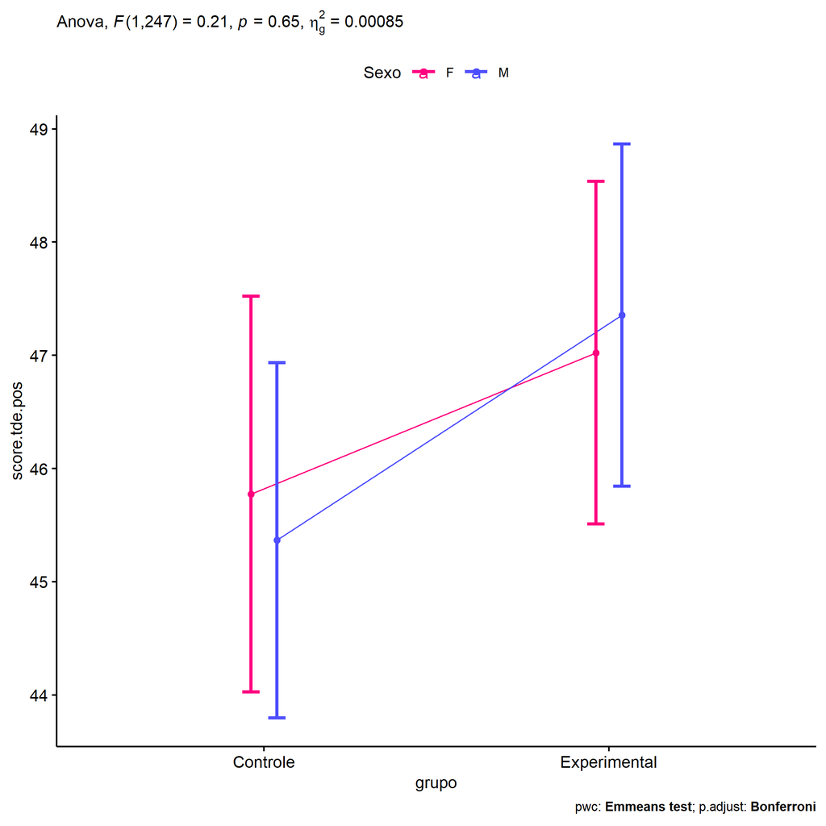

```r
if (!is.null(plots[["grupo"]]))
  plots[["grupo"]] + ggplot2::scale_color_manual(values = color[["Sexo"]])
```

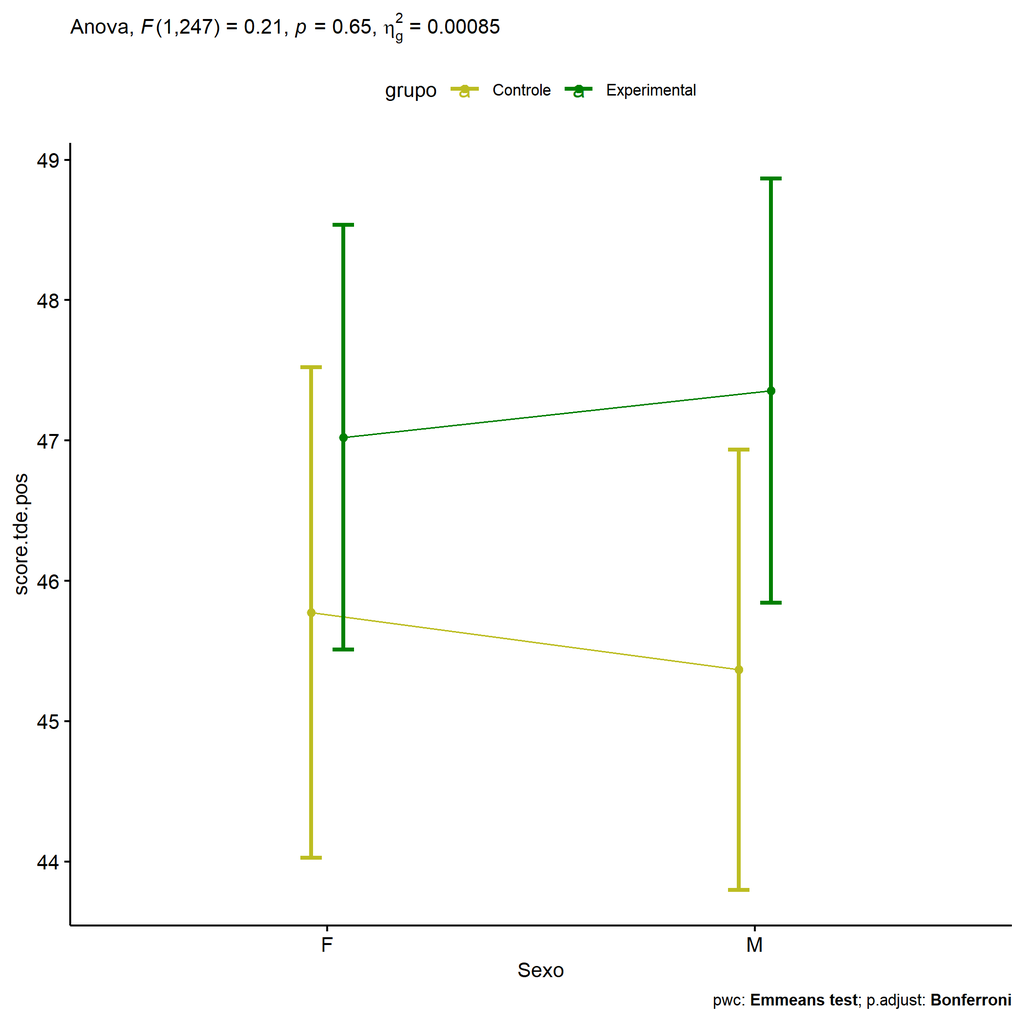

```r
if (!is.null(plots[["Sexo"]]))
  plots[["Sexo"]] + ggplot2::scale_color_manual(values = color[["grupo"]])
```

```r
plots <- twoWayAncovaBoxPlots(
  wdat, "score.tde.pos", c("grupo","Sexo"), aov, pwcs, covar = "score.tde.pre",
  theme = "classic", color = color[["grupo:Sexo"]],
  subtitle = which(aov$Effect == "grupo:Sexo"))
```

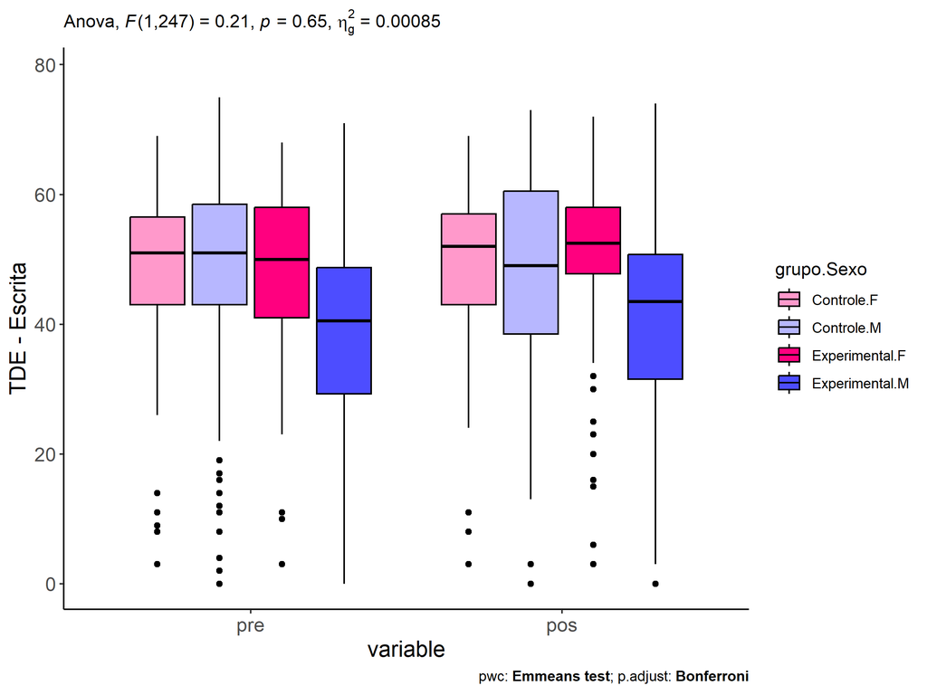

```r
plots[["grupo:Sexo"]] + ggplot2::ylab("TDE - Escrita") + ggplot2::scale_x_discrete(labels=c('pre', 'pos'))
```

```r
plots <- twoWayAncovaBoxPlots(
  wdat.long, "score.tde", c("grupo","Sexo"), aov, pwc.long, pre.post = "time",
  theme = "classic", color = color$prepost)
```

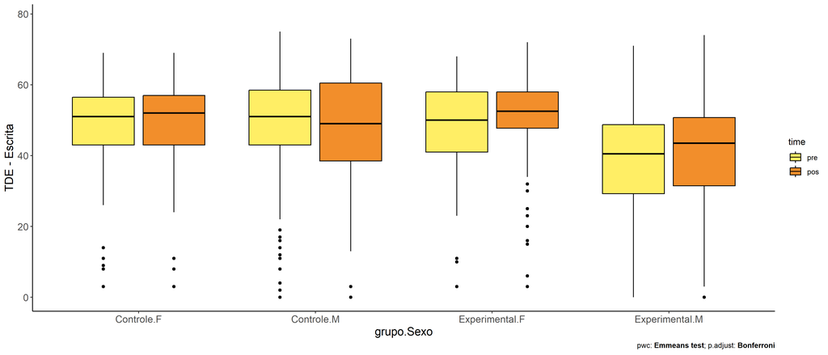

```r
plots[["grupo:Sexo"]] + ggplot2::ylab("TDE - Escrita")
```

### Checking linearity assumption

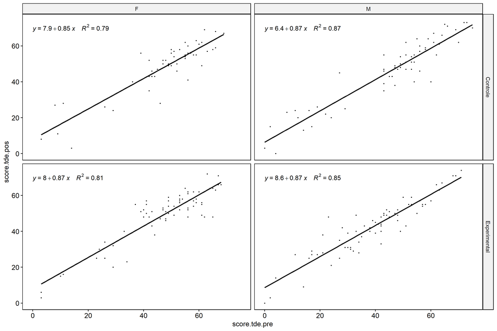

```r
ggscatter(wdat, x = "score.tde.pre", y = "score.tde.pos", size = 0.5,
          facet.by = c("grupo","Sexo"), add = "reg.line")+
  stat_regline_equation(
    aes(label =  paste(..eq.label.., ..rr.label.., sep = "~~~~"))
  )
```

### Checking normality and homogeneity

```r
res <- augment(lm(score.tde.pos ~ score.tde.pre + grupo*Sexo, data = wdat))
```

```r
shapiro_test(res$.resid)
```

```
## # A tibble: 1 × 3
##   variable   statistic p.value
##   <chr>          <dbl>   <dbl>
## 1 res$.resid     0.989  0.0520
```

```r
levene_test(res, .resid ~ grupo*Sexo)
```

```
## # A tibble: 1 × 4
##     df1   df2 statistic     p
##   <int> <int>     <dbl> <dbl>
## 1     3   248     0.259 0.855
```

# ANCOVA and Pairwise for two factors **grupo:Zona**

## Without remove non-normal data

```r
pdat = remove_group_data(dat[!is.na(dat[["grupo"]]) & !is.na(dat[["Zona"]]),], "score.tde.pos", c("grupo","Zona"))

pdat.long <- rbind(pdat[,c("id","grupo","Zona")], pdat[,c("id","grupo","Zona")])
pdat.long[["time"]] <- c(rep("pre", nrow(pdat)), rep("pos", nrow(pdat)))
pdat.long[["time"]] <- factor(pdat.long[["time"]], c("pre","pos"))
pdat.long[["score.tde"]] <- c(pdat[["score.tde.pre"]], pdat[["score.tde.pos"]])

aov = anova_test(pdat, score.tde.pos ~ score.tde.pre + grupo*Zona)
laov[["grupo:Zona"]] <- get_anova_table(aov)
```

```r
pwcs <- list()
pwcs[["Zona"]] <- emmeans_test(
  group_by(pdat, grupo), score.tde.pos ~ Zona,
  covariate = score.tde.pre, p.adjust.method = "bonferroni")
pwcs[["grupo"]] <- emmeans_test(
  group_by(pdat, Zona), score.tde.pos ~ grupo,
  covariate = score.tde.pre, p.adjust.method = "bonferroni")

pwc <- plyr::rbind.fill(pwcs[["grupo"]], pwcs[["Zona"]])
pwc <- pwc[,c("grupo","Zona", colnames(pwc)[!colnames(pwc) %in% c("grupo","Zona")])]
```

```r
pwc.long <- emmeans_test(dplyr::group_by_at(pdat.long, c("grupo","Zona")),
                         score.tde ~ time,
                         p.adjust.method = "bonferroni")
lpwc[["grupo:Zona"]] <- plyr::rbind.fill(pwc, pwc.long)
```

```r
ds <- get.descriptives(pdat, "score.tde.pos", c("grupo","Zona"), covar = "score.tde.pre")
ds <- merge(ds[ds$variable != "score.tde.pre",],
            ds[ds$variable == "score.tde.pre", !colnames(ds) %in% c("variable")],
            by = c("grupo","Zona"), all.x = T, suffixes = c("", ".score.tde.pre"))
ds <- merge(get_emmeans(pwcs[["grupo"]]), ds, by = c("grupo","Zona"), suffixes = c(".emms", ""))
ds <- ds[,c("grupo","Zona","n","mean.score.tde.pre","se.score.tde.pre","mean","se","emmean","se.emms")]

colnames(ds) <- c("grupo","Zona", "N", paste0(c("M","SE")," (pre)"),
                  paste0(c("M","SE"), " (unadj)"), paste0(c("M", "SE"), " (adj)"))

lemms[["grupo:Zona"]] <- ds
```

## Computing ANCOVA and PairWise After removing non-normal data (OK)

```r
wdat = pdat

res = residuals(lm(score.tde.pos ~ score.tde.pre + grupo*Zona, data = wdat))
non.normal = getNonNormal(res, wdat$id, plimit = 0.05)

wdat = wdat[!wdat$id %in% non.normal,]

wdat.long <- rbind(wdat[,c("id","grupo","Zona")], wdat[,c("id","grupo","Zona")])
wdat.long[["time"]] <- c(rep("pre", nrow(wdat)), rep("pos", nrow(wdat)))
wdat.long[["time"]] <- factor(wdat.long[["time"]], c("pre","pos"))
wdat.long[["score.tde"]] <- c(wdat[["score.tde.pre"]], wdat[["score.tde.pos"]])


ldat[["grupo:Zona"]] = wdat

(non.normal)
```

```
## [1] "P1117" "P1139" "P3228" "P1152" "P3732" "P609"  "P606"
```

```r
aov = anova_test(wdat, score.tde.pos ~ score.tde.pre + grupo*Zona)
laov[["grupo:Zona"]] <- merge(get_anova_table(aov), laov[["grupo:Zona"]], by="Effect", suffixes = c("","'"))

(df = get_anova_table(aov))
```

```
## ANOVA Table (type II tests)
##
##          Effect DFn DFd       F        p p<.05   ges
## 1 score.tde.pre   1 136 795.840 1.08e-58     * 0.854
## 2         grupo   1 136   5.923 1.60e-02     * 0.042
## 3          Zona   1 136   1.026 3.13e-01       0.007
## 4    grupo:Zona   1 136   1.344 2.48e-01       0.010
```

| Effect | DFn | DFd | F | p | p<.05 | ges |
| --- | --- | --- | --- | --- | --- | --- |
| score.tde.pre | 1 | 136 | 795.840 | 0.000 | * | 0.854 |
| grupo | 1 | 136 | 5.923 | 0.016 | * | 0.042 |
| Zona | 1 | 136 | 1.026 | 0.313 |  | 0.007 |
| grupo:Zona | 1 | 136 | 1.344 | 0.248 |  | 0.010 |

```r
pwcs <- list()
pwcs[["Zona"]] <- emmeans_test(
  group_by(wdat, grupo), score.tde.pos ~ Zona,
  covariate = score.tde.pre, p.adjust.method = "bonferroni")
pwcs[["grupo"]] <- emmeans_test(
  group_by(wdat, Zona), score.tde.pos ~ grupo,
  covariate = score.tde.pre, p.adjust.method = "bonferroni")

pwc <- plyr::rbind.fill(pwcs[["grupo"]], pwcs[["Zona"]])
pwc <- pwc[,c("grupo","Zona", colnames(pwc)[!colnames(pwc) %in% c("grupo","Zona")])]
```

| grupo | Zona | term | .y. | group1 | group2 | df | statistic | p | p.adj | p.adj.signif |
| --- | --- | --- | --- | --- | --- | --- | --- | --- | --- | --- |
|  | Rural | score.tde.pre*grupo | score.tde.pos | Controle | Experimental | 136 | -1.499 | 0.136 | 0.136 | ns |
|  | Urbana | score.tde.pre*grupo | score.tde.pos | Controle | Experimental | 136 | -2.281 | 0.024 | 0.024 | * |
| Controle |  | score.tde.pre*Zona | score.tde.pos | Rural | Urbana | 136 | 1.533 | 0.128 | 0.128 | ns |
| Experimental |  | score.tde.pre*Zona | score.tde.pos | Rural | Urbana | 136 | 0.129 | 0.898 | 0.898 | ns |

```r
pwc.long <- emmeans_test(dplyr::group_by_at(wdat.long, c("grupo","Zona")),
                         score.tde ~ time,
                         p.adjust.method = "bonferroni")
lpwc[["grupo:Zona"]] <- merge(plyr::rbind.fill(pwc, pwc.long), lpwc[["grupo:Zona"]], by=c("grupo","Zona","term",".y.","group1","group2"), suffixes = c("","'"))
```

| grupo | Zona | term | .y. | group1 | group2 | df | statistic | p | p.adj | p.adj.signif |
| --- | --- | --- | --- | --- | --- | --- | --- | --- | --- | --- |
| Controle | Rural | time | score.tde | pre | pos | 274 | -0.007 | 0.995 | 0.995 | ns |
| Controle | Urbana | time | score.tde | pre | pos | 274 | 0.608 | 0.543 | 0.543 | ns |
| Experimental | Rural | time | score.tde | pre | pos | 274 | -0.743 | 0.458 | 0.458 | ns |
| Experimental | Urbana | time | score.tde | pre | pos | 274 | -0.579 | 0.563 | 0.563 | ns |

```r
ds <- get.descriptives(wdat, "score.tde.pos", c("grupo","Zona"), covar = "score.tde.pre")
ds <- merge(ds[ds$variable != "score.tde.pre",],
            ds[ds$variable == "score.tde.pre", !colnames(ds) %in% c("variable")],
            by = c("grupo","Zona"), all.x = T, suffixes = c("", ".score.tde.pre"))
ds <- merge(get_emmeans(pwcs[["grupo"]]), ds, by = c("grupo","Zona"), suffixes = c(".emms", ""))
ds <- ds[,c("grupo","Zona","n","mean.score.tde.pre","se.score.tde.pre","mean","se","emmean","se.emms")]

colnames(ds) <- c("grupo","Zona", "N", paste0(c("M","SE")," (pre)"),
                  paste0(c("M","SE"), " (unadj)"), paste0(c("M", "SE"), " (adj)"))

lemms[["grupo:Zona"]] <- merge(ds, lemms[["grupo:Zona"]], by=c("grupo","Zona"), suffixes = c("","'"))
```

| grupo | Zona | N | M (pre) | SE (pre) | M (unadj) | SE (unadj) | M (adj) | SE (adj) |
| --- | --- | --- | --- | --- | --- | --- | --- | --- |
| Controle | Rural | 43 | 47.698 | 2.243 | 47.721 | 2.354 | 45.616 | 0.956 |
| Controle | Urbana | 14 | 56.571 | 3.868 | 52.786 | 3.408 | 42.634 | 1.709 |
| Experimental | Rural | 53 | 43.208 | 2.524 | 45.585 | 2.388 | 47.551 | 0.862 |
| Experimental | Urbana | 31 | 40.806 | 3.019 | 43.226 | 3.039 | 47.369 | 1.132 |

### Plots for ancova

```r
plots <- twoWayAncovaPlots(
  wdat, "score.tde.pos", c("grupo","Zona"), aov, pwcs, addParam = c("mean_se"),
  font.label.size=10, step.increase=0.05, p.label="p.adj",
  subtitle = which(aov$Effect == "grupo:Zona"))
```

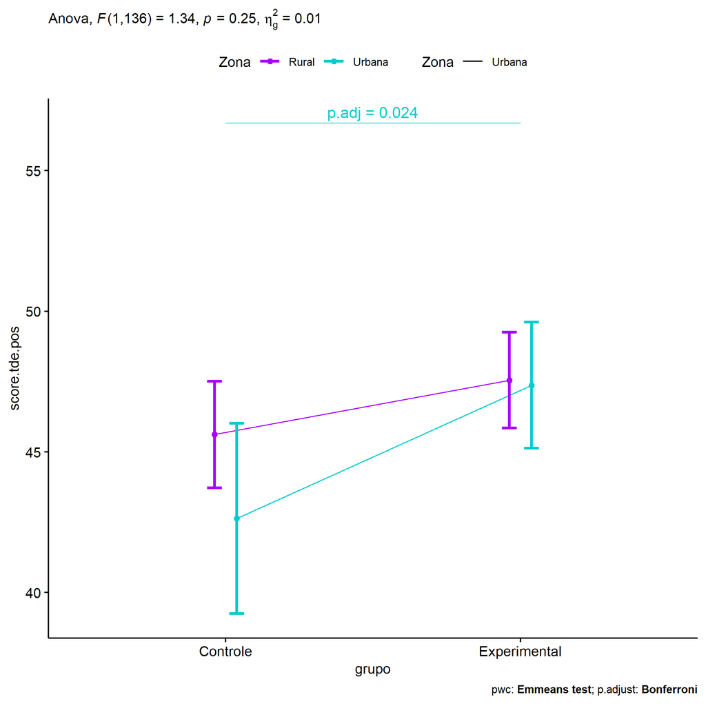

```r
if (!is.null(plots[["grupo"]]))
  plots[["grupo"]] + ggplot2::scale_color_manual(values = color[["Zona"]])
```

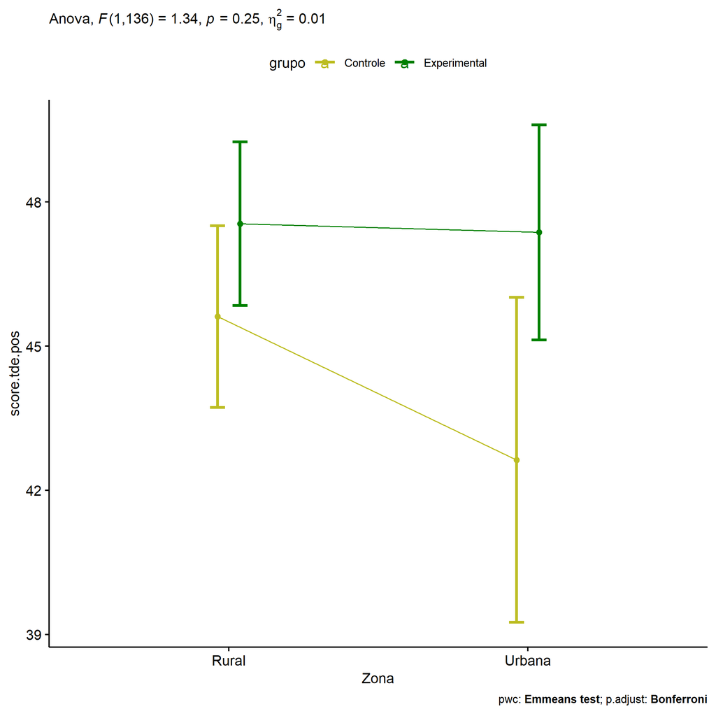

```r
if (!is.null(plots[["Zona"]]))
  plots[["Zona"]] + ggplot2::scale_color_manual(values = color[["grupo"]])
```

```r
plots <- twoWayAncovaBoxPlots(
  wdat, "score.tde.pos", c("grupo","Zona"), aov, pwcs, covar = "score.tde.pre",
  theme = "classic", color = color[["grupo:Zona"]],
  subtitle = which(aov$Effect == "grupo:Zona"))
```

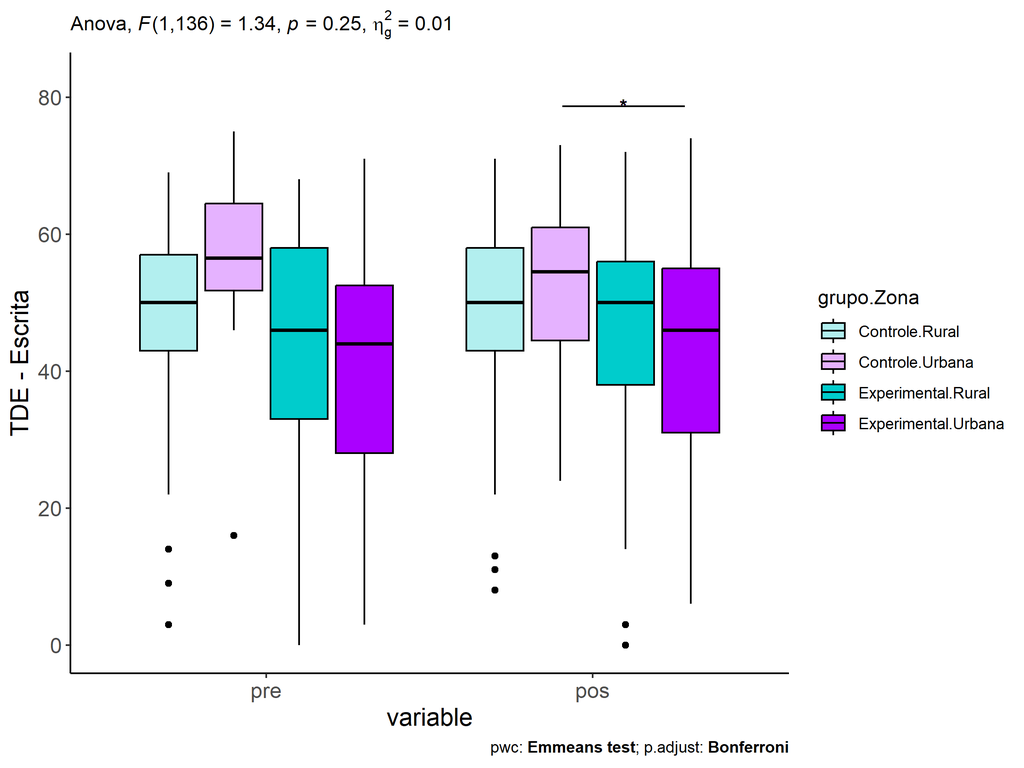

```r
plots[["grupo:Zona"]] + ggplot2::ylab("TDE - Escrita") + ggplot2::scale_x_discrete(labels=c('pre', 'pos'))
```

```r
plots <- twoWayAncovaBoxPlots(
  wdat.long, "score.tde", c("grupo","Zona"), aov, pwc.long, pre.post = "time",
  theme = "classic", color = color$prepost)
```

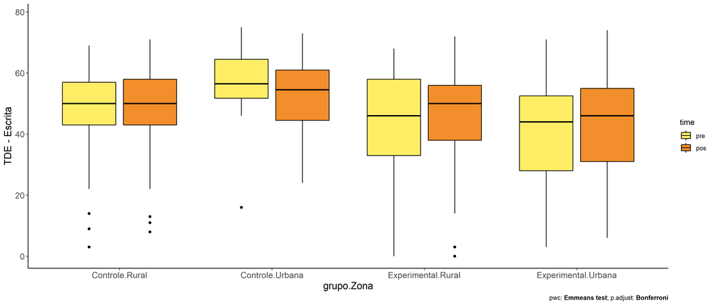

```r
plots[["grupo:Zona"]] + ggplot2::ylab("TDE - Escrita")
```

### Checking linearity assumption

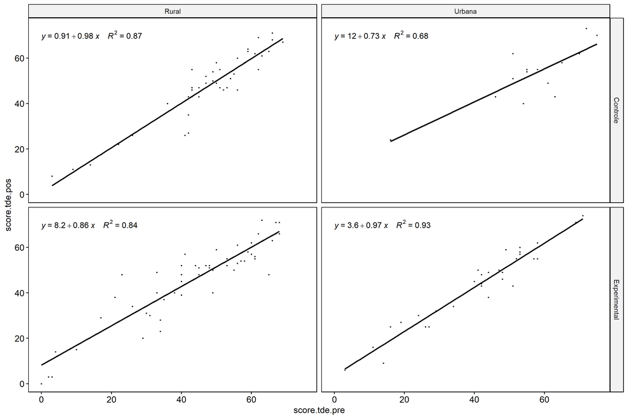

```r
ggscatter(wdat, x = "score.tde.pre", y = "score.tde.pos", size = 0.5,
          facet.by = c("grupo","Zona"), add = "reg.line")+
  stat_regline_equation(
    aes(label =  paste(..eq.label.., ..rr.label.., sep = "~~~~"))
  )
```

### Checking normality and homogeneity

```r
res <- augment(lm(score.tde.pos ~ score.tde.pre + grupo*Zona, data = wdat))
```

```r
shapiro_test(res$.resid)
```

```
## # A tibble: 1 × 3
##   variable   statistic p.value
##   <chr>          <dbl>   <dbl>
## 1 res$.resid     0.980  0.0410
```

```r
levene_test(res, .resid ~ grupo*Zona)
```

```
## # A tibble: 1 × 4
##     df1   df2 statistic     p
##   <int> <int>     <dbl> <dbl>
## 1     3   137      1.70 0.170
```

# ANCOVA and Pairwise for two factors **grupo:Cor.Raca**

## Without remove non-normal data

```r
pdat = remove_group_data(dat[!is.na(dat[["grupo"]]) & !is.na(dat[["Cor.Raca"]]),], "score.tde.pos", c("grupo","Cor.Raca"))

pdat.long <- rbind(pdat[,c("id","grupo","Cor.Raca")], pdat[,c("id","grupo","Cor.Raca")])
pdat.long[["time"]] <- c(rep("pre", nrow(pdat)), rep("pos", nrow(pdat)))
pdat.long[["time"]] <- factor(pdat.long[["time"]], c("pre","pos"))
pdat.long[["score.tde"]] <- c(pdat[["score.tde.pre"]], pdat[["score.tde.pos"]])

aov = anova_test(pdat, score.tde.pos ~ score.tde.pre + grupo*Cor.Raca)
laov[["grupo:Cor.Raca"]] <- get_anova_table(aov)
```

```r
pwcs <- list()
pwcs[["Cor.Raca"]] <- emmeans_test(
  group_by(pdat, grupo), score.tde.pos ~ Cor.Raca,
  covariate = score.tde.pre, p.adjust.method = "bonferroni")
pwcs[["grupo"]] <- emmeans_test(
  group_by(pdat, Cor.Raca), score.tde.pos ~ grupo,
  covariate = score.tde.pre, p.adjust.method = "bonferroni")

pwc <- plyr::rbind.fill(pwcs[["grupo"]], pwcs[["Cor.Raca"]])
pwc <- pwc[,c("grupo","Cor.Raca", colnames(pwc)[!colnames(pwc) %in% c("grupo","Cor.Raca")])]
```

```r
pwc.long <- emmeans_test(dplyr::group_by_at(pdat.long, c("grupo","Cor.Raca")),
                         score.tde ~ time,
                         p.adjust.method = "bonferroni")
lpwc[["grupo:Cor.Raca"]] <- plyr::rbind.fill(pwc, pwc.long)
```

```r
ds <- get.descriptives(pdat, "score.tde.pos", c("grupo","Cor.Raca"), covar = "score.tde.pre")
ds <- merge(ds[ds$variable != "score.tde.pre",],
            ds[ds$variable == "score.tde.pre", !colnames(ds) %in% c("variable")],
            by = c("grupo","Cor.Raca"), all.x = T, suffixes = c("", ".score.tde.pre"))
ds <- merge(get_emmeans(pwcs[["grupo"]]), ds, by = c("grupo","Cor.Raca"), suffixes = c(".emms", ""))
ds <- ds[,c("grupo","Cor.Raca","n","mean.score.tde.pre","se.score.tde.pre","mean","se","emmean","se.emms")]

colnames(ds) <- c("grupo","Cor.Raca", "N", paste0(c("M","SE")," (pre)"),
                  paste0(c("M","SE"), " (unadj)"), paste0(c("M", "SE"), " (adj)"))

lemms[["grupo:Cor.Raca"]] <- ds
```

## Computing ANCOVA and PairWise After removing non-normal data (OK)

```r
wdat = pdat

res = residuals(lm(score.tde.pos ~ score.tde.pre + grupo*Cor.Raca, data = wdat))
non.normal = getNonNormal(res, wdat$id, plimit = 0.05)

wdat = wdat[!wdat$id %in% non.normal,]

wdat.long <- rbind(wdat[,c("id","grupo","Cor.Raca")], wdat[,c("id","grupo","Cor.Raca")])
wdat.long[["time"]] <- c(rep("pre", nrow(wdat)), rep("pos", nrow(wdat)))
wdat.long[["time"]] <- factor(wdat.long[["time"]], c("pre","pos"))
wdat.long[["score.tde"]] <- c(wdat[["score.tde.pre"]], wdat[["score.tde.pos"]])


ldat[["grupo:Cor.Raca"]] = wdat

(non.normal)
```

```
## [1] "P1128" "P1139"
```

```r
aov = anova_test(wdat, score.tde.pos ~ score.tde.pre + grupo*Cor.Raca)
laov[["grupo:Cor.Raca"]] <- merge(get_anova_table(aov), laov[["grupo:Cor.Raca"]], by="Effect", suffixes = c("","'"))

(df = get_anova_table(aov))
```

```
## ANOVA Table (type II tests)
##
##           Effect DFn DFd       F        p p<.05      ges
## 1  score.tde.pre   1 109 246.347 9.76e-30     * 0.693000
## 2          grupo   1 109   0.074 7.87e-01       0.000676
## 3       Cor.Raca   1 109   1.585 2.11e-01       0.014000
## 4 grupo:Cor.Raca   1 109   0.285 5.94e-01       0.003000
```

| Effect | DFn | DFd | F | p | p<.05 | ges |
| --- | --- | --- | --- | --- | --- | --- |
| score.tde.pre | 1 | 109 | 246.347 | 0.000 | * | 0.693 |
| grupo | 1 | 109 | 0.074 | 0.787 |  | 0.001 |
| Cor.Raca | 1 | 109 | 1.585 | 0.211 |  | 0.014 |
| grupo:Cor.Raca | 1 | 109 | 0.285 | 0.594 |  | 0.003 |

```r
pwcs <- list()
pwcs[["Cor.Raca"]] <- emmeans_test(
  group_by(wdat, grupo), score.tde.pos ~ Cor.Raca,
  covariate = score.tde.pre, p.adjust.method = "bonferroni")
pwcs[["grupo"]] <- emmeans_test(
  group_by(wdat, Cor.Raca), score.tde.pos ~ grupo,
  covariate = score.tde.pre, p.adjust.method = "bonferroni")

pwc <- plyr::rbind.fill(pwcs[["grupo"]], pwcs[["Cor.Raca"]])
pwc <- pwc[,c("grupo","Cor.Raca", colnames(pwc)[!colnames(pwc) %in% c("grupo","Cor.Raca")])]
```

| grupo | Cor.Raca | term | .y. | group1 | group2 | df | statistic | p | p.adj | p.adj.signif |
| --- | --- | --- | --- | --- | --- | --- | --- | --- | --- | --- |
|  | Branca | score.tde.pre*grupo | score.tde.pos | Controle | Experimental | 109 | 0.387 | 0.699 | 0.699 | ns |
|  | Parda | score.tde.pre*grupo | score.tde.pos | Controle | Experimental | 109 | -0.456 | 0.649 | 0.649 | ns |
| Controle |  | score.tde.pre*Cor.Raca | score.tde.pos | Branca | Parda | 109 | 1.268 | 0.208 | 0.208 | ns |
| Experimental |  | score.tde.pre*Cor.Raca | score.tde.pos | Branca | Parda | 109 | 0.566 | 0.573 | 0.573 | ns |

```r
pwc.long <- emmeans_test(dplyr::group_by_at(wdat.long, c("grupo","Cor.Raca")),
                         score.tde ~ time,
                         p.adjust.method = "bonferroni")
lpwc[["grupo:Cor.Raca"]] <- merge(plyr::rbind.fill(pwc, pwc.long), lpwc[["grupo:Cor.Raca"]], by=c("grupo","Cor.Raca","term",".y.","group1","group2"), suffixes = c("","'"))
```

| grupo | Cor.Raca | term | .y. | group1 | group2 | df | statistic | p | p.adj | p.adj.signif |
| --- | --- | --- | --- | --- | --- | --- | --- | --- | --- | --- |
| Controle | Branca | time | score.tde | pre | pos | 220 | -0.144 | 0.886 | 0.886 | ns |
| Controle | Parda | time | score.tde | pre | pos | 220 | 0.271 | 0.787 | 0.787 | ns |
| Experimental | Branca | time | score.tde | pre | pos | 220 | 0.014 | 0.989 | 0.989 | ns |
| Experimental | Parda | time | score.tde | pre | pos | 220 | -0.154 | 0.877 | 0.877 | ns |

```r
ds <- get.descriptives(wdat, "score.tde.pos", c("grupo","Cor.Raca"), covar = "score.tde.pre")
ds <- merge(ds[ds$variable != "score.tde.pre",],
            ds[ds$variable == "score.tde.pre", !colnames(ds) %in% c("variable")],
            by = c("grupo","Cor.Raca"), all.x = T, suffixes = c("", ".score.tde.pre"))
ds <- merge(get_emmeans(pwcs[["grupo"]]), ds, by = c("grupo","Cor.Raca"), suffixes = c(".emms", ""))
ds <- ds[,c("grupo","Cor.Raca","n","mean.score.tde.pre","se.score.tde.pre","mean","se","emmean","se.emms")]

colnames(ds) <- c("grupo","Cor.Raca", "N", paste0(c("M","SE")," (pre)"),
                  paste0(c("M","SE"), " (unadj)"), paste0(c("M", "SE"), " (adj)"))

lemms[["grupo:Cor.Raca"]] <- merge(ds, lemms[["grupo:Cor.Raca"]], by=c("grupo","Cor.Raca"), suffixes = c("","'"))
```

| grupo | Cor.Raca | N | M (pre) | SE (pre) | M (unadj) | SE (unadj) | M (adj) | SE (adj) |
| --- | --- | --- | --- | --- | --- | --- | --- | --- |
| Controle | Branca | 8 | 54.750 | 2.839 | 56.000 | 3.495 | 45.125 | 3.455 |
| Controle | Parda | 50 | 40.940 | 2.524 | 40.000 | 2.465 | 40.415 | 1.354 |
| Experimental | Branca | 9 | 52.333 | 3.902 | 52.222 | 4.853 | 43.322 | 3.241 |
| Experimental | Parda | 47 | 37.638 | 2.773 | 38.191 | 2.660 | 41.306 | 1.410 |

### Plots for ancova

```r
plots <- twoWayAncovaPlots(
  wdat, "score.tde.pos", c("grupo","Cor.Raca"), aov, pwcs, addParam = c("mean_se"),
  font.label.size=10, step.increase=0.05, p.label="p.adj",
  subtitle = which(aov$Effect == "grupo:Cor.Raca"))
```

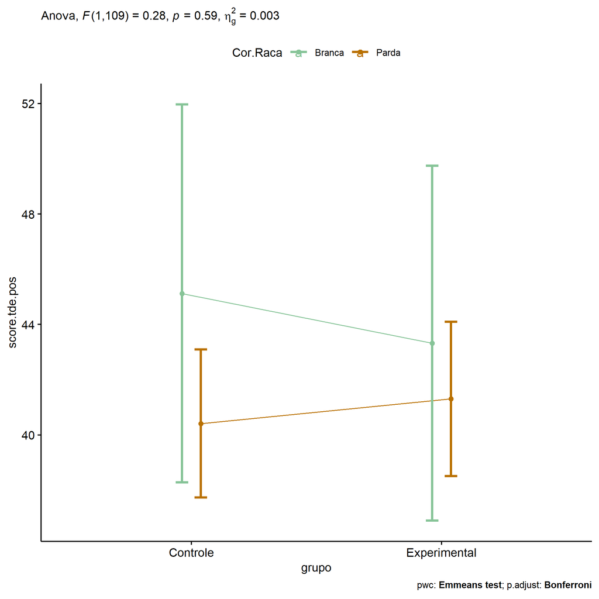

```r
if (!is.null(plots[["grupo"]]))
  plots[["grupo"]] + ggplot2::scale_color_manual(values = color[["Cor.Raca"]])
```

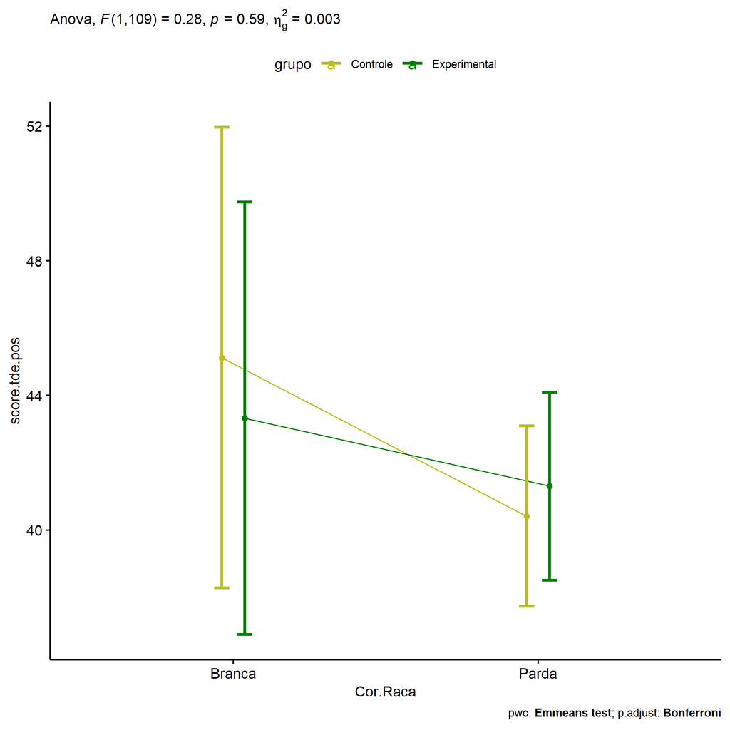

```r
if (!is.null(plots[["Cor.Raca"]]))
  plots[["Cor.Raca"]] + ggplot2::scale_color_manual(values = color[["grupo"]])
```

```r
plots <- twoWayAncovaBoxPlots(
  wdat, "score.tde.pos", c("grupo","Cor.Raca"), aov, pwcs, covar = "score.tde.pre",
  theme = "classic", color = color[["grupo:Cor.Raca"]],
  subtitle = which(aov$Effect == "grupo:Cor.Raca"))
```

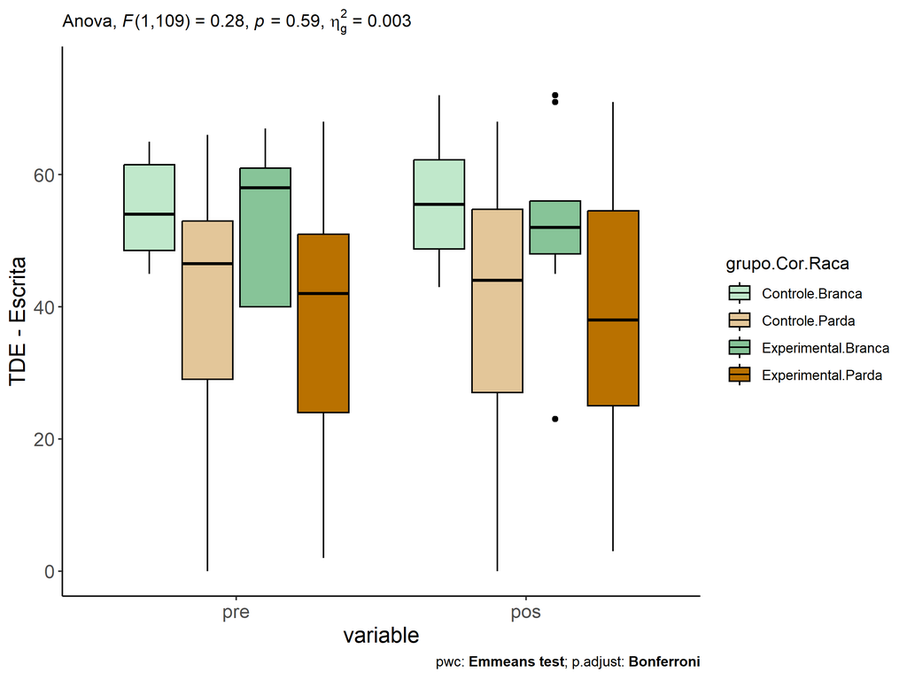

```r
plots[["grupo:Cor.Raca"]] + ggplot2::ylab("TDE - Escrita") + ggplot2::scale_x_discrete(labels=c('pre', 'pos'))
```

```r
plots <- twoWayAncovaBoxPlots(
  wdat.long, "score.tde", c("grupo","Cor.Raca"), aov, pwc.long, pre.post = "time",
  theme = "classic", color = color$prepost)
```

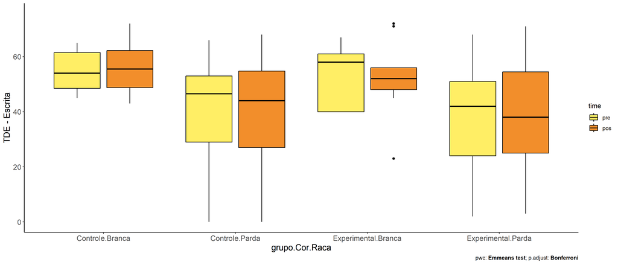

```r
plots[["grupo:Cor.Raca"]] + ggplot2::ylab("TDE - Escrita")
```

### Checking linearity assumption

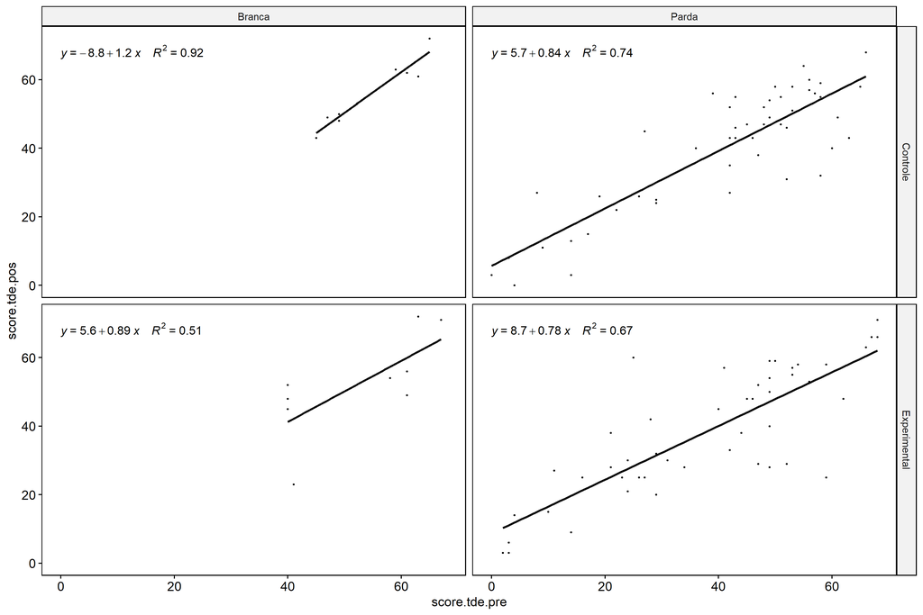

```r
ggscatter(wdat, x = "score.tde.pre", y = "score.tde.pos", size = 0.5,
          facet.by = c("grupo","Cor.Raca"), add = "reg.line")+
  stat_regline_equation(
    aes(label =  paste(..eq.label.., ..rr.label.., sep = "~~~~"))
  )
```

### Checking normality and homogeneity

```r
res <- augment(lm(score.tde.pos ~ score.tde.pre + grupo*Cor.Raca, data = wdat))
```

```r
shapiro_test(res$.resid)
```

```
## # A tibble: 1 × 3
##   variable   statistic p.value
##   <chr>          <dbl>   <dbl>
## 1 res$.resid     0.978  0.0535
```

```r
levene_test(res, .resid ~ grupo*Cor.Raca)
```

```
## # A tibble: 1 × 4
##     df1   df2 statistic     p
##   <int> <int>     <dbl> <dbl>
## 1     3   110      1.32 0.271
```

# ANCOVA and Pairwise for two factors **grupo:score.tde.quintile**

## Without remove non-normal data

```r
pdat = remove_group_data(dat[!is.na(dat[["grupo"]]) & !is.na(dat[["score.tde.quintile"]]),], "score.tde.pos", c("grupo","score.tde.quintile"))

pdat.long <- rbind(pdat[,c("id","grupo","score.tde.quintile")], pdat[,c("id","grupo","score.tde.quintile")])
pdat.long[["time"]] <- c(rep("pre", nrow(pdat)), rep("pos", nrow(pdat)))
pdat.long[["time"]] <- factor(pdat.long[["time"]], c("pre","pos"))
pdat.long[["score.tde"]] <- c(pdat[["score.tde.pre"]], pdat[["score.tde.pos"]])

aov = anova_test(pdat, score.tde.pos ~ score.tde.pre + grupo*score.tde.quintile)
laov[["grupo:score.tde.quintile"]] <- get_anova_table(aov)
```

```r
pwcs <- list()
pwcs[["score.tde.quintile"]] <- emmeans_test(
  group_by(pdat, grupo), score.tde.pos ~ score.tde.quintile,
  covariate = score.tde.pre, p.adjust.method = "bonferroni")
pwcs[["grupo"]] <- emmeans_test(
  group_by(pdat, score.tde.quintile), score.tde.pos ~ grupo,
  covariate = score.tde.pre, p.adjust.method = "bonferroni")

pwc <- plyr::rbind.fill(pwcs[["grupo"]], pwcs[["score.tde.quintile"]])
pwc <- pwc[,c("grupo","score.tde.quintile", colnames(pwc)[!colnames(pwc) %in% c("grupo","score.tde.quintile")])]
```

```r
pwc.long <- emmeans_test(dplyr::group_by_at(pdat.long, c("grupo","score.tde.quintile")),
                         score.tde ~ time,
                         p.adjust.method = "bonferroni")
lpwc[["grupo:score.tde.quintile"]] <- plyr::rbind.fill(pwc, pwc.long)
```

```r
ds <- get.descriptives(pdat, "score.tde.pos", c("grupo","score.tde.quintile"), covar = "score.tde.pre")
ds <- merge(ds[ds$variable != "score.tde.pre",],
            ds[ds$variable == "score.tde.pre", !colnames(ds) %in% c("variable")],
            by = c("grupo","score.tde.quintile"), all.x = T, suffixes = c("", ".score.tde.pre"))
ds <- merge(get_emmeans(pwcs[["grupo"]]), ds, by = c("grupo","score.tde.quintile"), suffixes = c(".emms", ""))
ds <- ds[,c("grupo","score.tde.quintile","n","mean.score.tde.pre","se.score.tde.pre","mean","se","emmean","se.emms")]

colnames(ds) <- c("grupo","score.tde.quintile", "N", paste0(c("M","SE")," (pre)"),
                  paste0(c("M","SE"), " (unadj)"), paste0(c("M", "SE"), " (adj)"))

lemms[["grupo:score.tde.quintile"]] <- ds
```